# Sampling Distribution Lecture

pronak@business.rutgers.edu

2/26/2022

## Magic of sampling

Lets say we know population mean is $\mu$ and std dev is $\sigma$. You take the sample samples from this population of size n.

Lets say the sample mean is $\mu_\bar{X}$ and std dev is $\sigma_\bar{X}$.

$\mu_\bar{x} = \mu$ and $sigma_\bar{x} = \sigma / \sqrt{n}$

We call $\sigma_\bar{x}$ as Standard Error. Based on the formula, as n goes up Standard Error goes down!

Magic is as long as n is large enough, you will see a normal distribution happening even if population distribution is not uniform. Let me demonstrate.

```r
x = rnorm(n=100, mean=0, sd=1)
mean(x)
```

```
## [1] 0.1262989
```

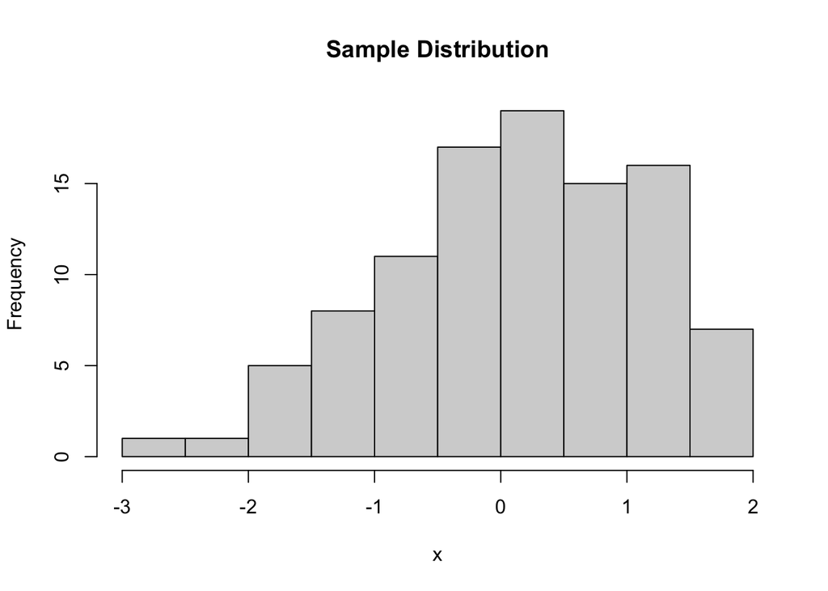

```r
hist(x, main="Sample Distribution")
```

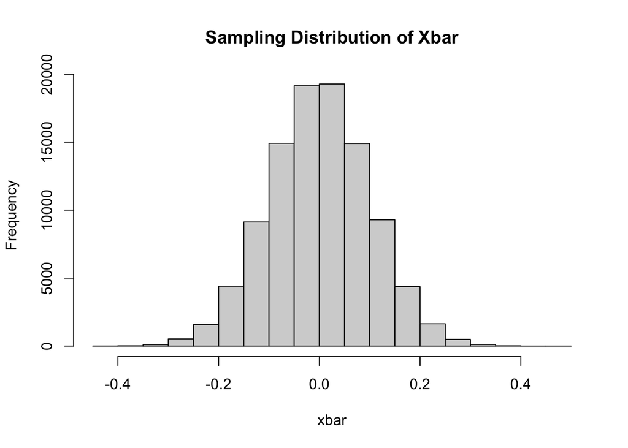

```r
# Lets take large samples of 100000
R = 100000
xbar = double(R)
for(r in 1:R){
    x = rnorm(n=100, mean=0, sd=1)
    xbar[r] = mean(x)
}
hist(xbar, main="Sampling Distribution of Xbar")
```

```r
mean(xbar)
```

```
## [1] 0.0001873644
```

```r
var(xbar)
```

```
## [1] 0.0100274
```

This works with non-uniform distribution. This is the beauty of central limit theorem (CLT).

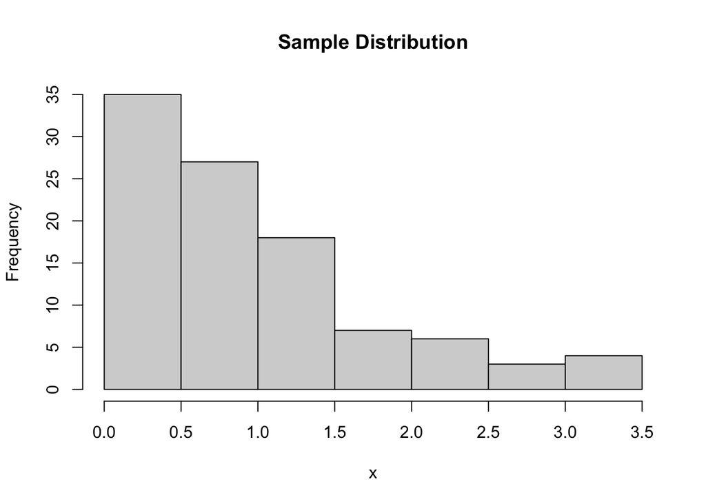

```r
x = rexp(n=100, rate=1)
hist(x, main="Sample Distribution")
```

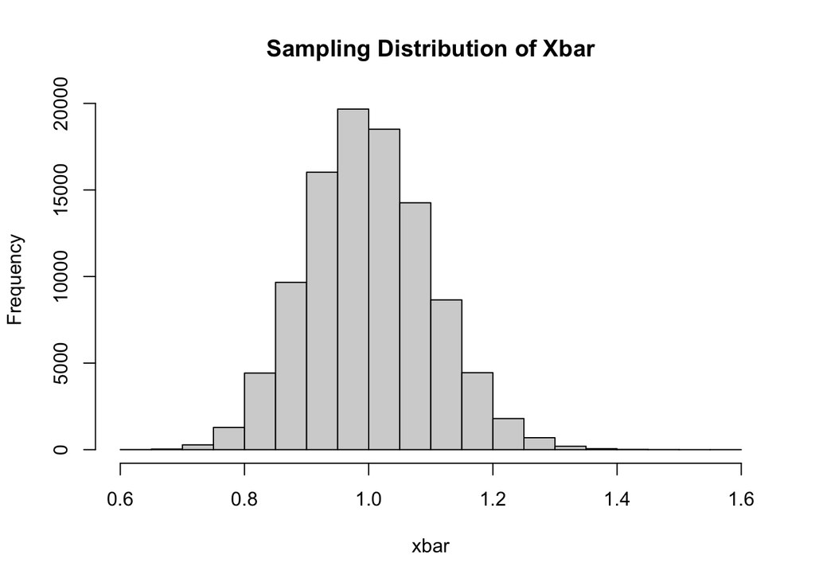

```r
R = 100000
xbar = double(R)
for(r in 1:R){
  x = rexp(n=100, rate=1)
  xbar[r] = mean(x)
}
hist(xbar, main="Sampling Distribution of Xbar")
```

```r
mean(xbar)
```

```
## [1] 1.000274
```

```r
var(xbar)
```

```
## [1] 0.009954631
```

To convert to standard normal distribution we can use

$Z = \frac{\bar{X}-\mu_p}{\sigma_p} = \frac{\bar{X}-\mu}{\frac{\sigma}{\sqrt{n}}}$

### Proportions - When value is qualitative

This works for proportions (when value is nominal or ordinal). Lets say population parameter is $\pi$ and sample population is represented by *p* where $*p* = X / n$, where *X* is items in sample with the characteristic. ] Then, $\mu_p = \pi$ and $\sigma_p =\sqrt{\frac{\pi(1-\pi)}{n}}$ and converting to standardized normal distribution we get, $Z = \frac{p-\pi}{\sigma_p} = \frac{p-\pi}{\sqrt{\frac{\pi(1-\pi)}{n}}}$

### Magic Numbers - Rule of Thumb

- For most distributions, n > 30 will give a sampling distribution that is nearly normal.
- For fairly symmetric distributions, n > 15 is large enough.
- For a normal population distribution, the sampling distribution of the mean is always normally distributed.
- For propotions, $n\pi \ge 5$ and $n(1-\pi) \ge 5$

## Confidence Intervals

Confidence Intervals (CI) is represented as $1 - \alpha$ and shown as % level of confidence. Hence, 95% CU means $1 - \alpha = .95$ and $\alpha = 0.05$ or 5% and $\frac{\alpha}{2} = .025$ or 2.5%.

CI = PE $\pm$ (Critical Value) (Standard Error), where PE refers to point estimate, and Critical Value refers to cut off of the Z-Score or t-Value. Standard Error refers to $\frac{\sigma}{\sqrt{n}}$

###Same notations

| Syntax | Population | Sample |
| --- | --- | --- |
| Mean | $\mu$ | $\bar{X}$ |
| Standard Deviation | $\sigma$ | $S$ |
| Proportion | $\pi$ | $p$ |

### Formula for different scenerios

- For estimating population mean with known population standard deviation $\sigma$
  $$CI = \bar{X} \pm Z_\frac{\alpha}{2}\frac{\sigma}{\sqrt{n}}$$
- For estimating population mean with unknown population standard deviation $\sigma$, we use sample standard deviation $S$
  $$CI = \bar{X} \pm t_\left(df,_\frac{\alpha}{2}\right)\frac{\mathrm{S}}{\sqrt{n}}$$
- For estimation population proportion $\pi$,
  $$CI = \mathrm{p} \pm Z_\frac{\alpha}{2} \sqrt{\frac{\mathrm{p}\left(1 - \mathrm{p} \right)}{\mathrm{n}}}$$
  The interpretation of confidence intervals is: if repeated samples were taken from the population and the 95% confidence interval computed for each sample, 95% of the intervals would contain the population mean in the long run. Let’s see if we can simulate the implication with R.

Say we send a few students to the food hall to sample and measure the mean weight of the soda in ounces. They each take a sample of 20 sodas, and construct a 95% confidence interval from their sample. For example, the following would be one possible realization of a confidence interval computed in this manner:

```r
library("BSDA")
soda.batch <- rnorm(n = 20, mean = 40, sd = 2)
test3 <- z.test(soda.batch, sigma.x = 2, conf.level = 0.95)
test3$conf.int
```

```
## [1] 39.32334 41.07638
## attr(,"conf.level")
## [1] 0.95
```

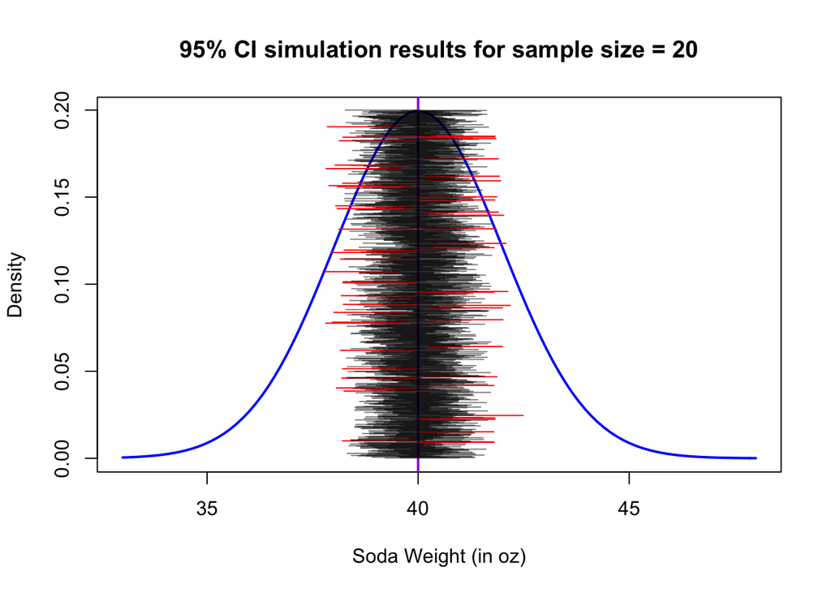

```r
# Lets do this a 1000 times!
attempts = 1000
curve(expr = dnorm(x, mean = 40, sd = 2), from = 33, to = 48,
      main = "95% CI simulation results for sample size = 20",
      xlab = "Soda Weight (in oz)", ylab = "Density",
      lwd=2, col="blue")
abline(v = 40, col = "purple", lwd = 2)
failed_to_contain <- 0
for (i in 1:attempts) {
    col <- rgb(0,0,0,0.5)
    soda.batch <- rnorm(n = 20, mean = 40, sd = 2)
    myCI <- z.test(soda.batch, sigma.x = 2, conf.level = 0.95)$conf.int
    if (min(myCI) > 40 | max(myCI) < 40) {
        failed_to_contain <- failed_to_contain + 1
        col <- rgb(1,0,0,1)
    }
    segments(min(myCI), 0.2 * i / attempts,
             max(myCI), 0.2 * i / attempts,
             lwd = 1, col = col)
}
```

```r
failed_to_contain
```

```
## [1] 55
```

```r
failed_to_contain / attempts
```

```
## [1] 0.055
```

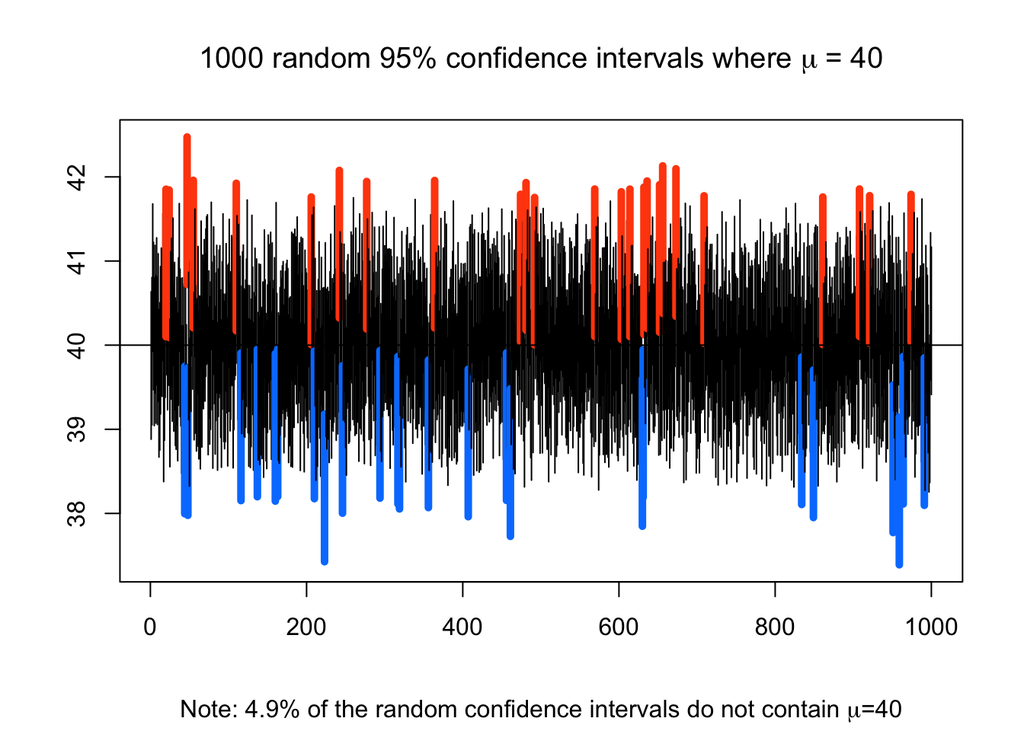

```
## 4.9 % of the random confidence intervals do not contain Mu = 40 .
```

```r
# OR you can use CI Sim
CIsim(samples=1000,n=20,mu=40,sigma=2,conf.level = .95,type = "Mean")
```

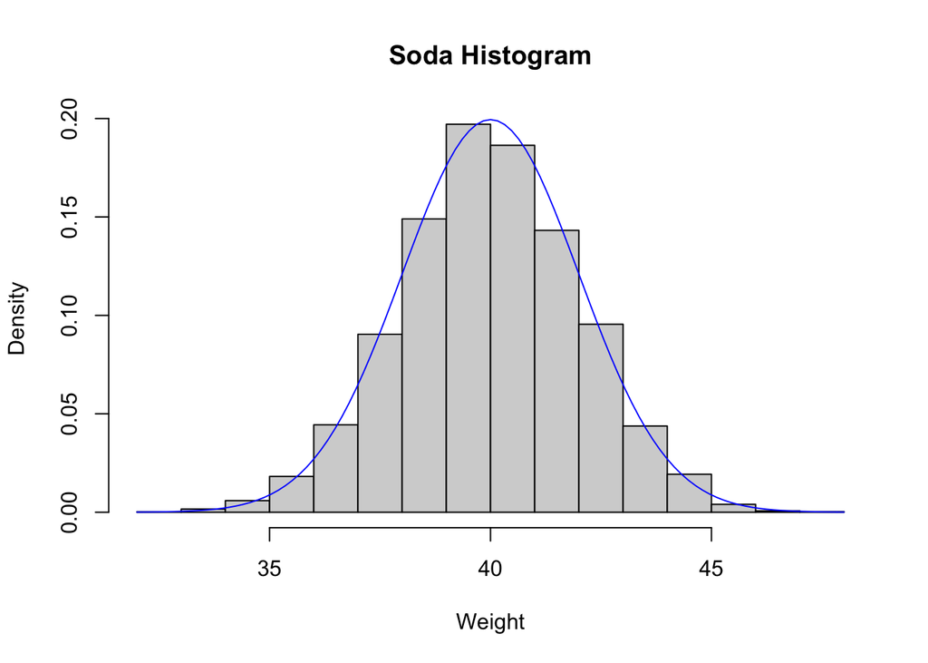

```r
# In a large soda you are suppose to get 40 ounces. However, the machine can sometimes dispense more of less soda. It is estimated the standard deviation is 2 ounces. Lets simulate this process.

set.seed(1)
soda <- rnorm(10000, mean = 40, sd = 2)
hist(soda, freq = FALSE, main = "Soda Histogram", xlab = "Weight")
curve(dnorm(x, mean = 40, sd = 2), col = "blue", add = TRUE)
```

```r
summary(soda)
```

```
##    Min. 1st Qu.  Median    Mean 3rd Qu.    Max.
##   32.66   38.65   39.97   39.99   41.36   47.62
```

```r
library("BSDA")
# When we know population standard deviation
test1 <- z.test(soda, sigma.x = 2, conf.level = 0.95)
test1$conf.int
```

```
## [1] 39.94773 40.02613
## attr(,"conf.level")
## [1] 0.95
```

```r
# when we do not know population standard deviation
test2 <- t.test(soda, conf.level = 0.95)
test2$conf.int
```

```
## [1] 39.94724 40.02661
## attr(,"conf.level")
## [1] 0.95
```

## Calculate Sample Size

A required sample size can be found for a desired margin of error $\mathrm{e}$ with a specified level of confidence $\left(1 - \alpha \right)$

Margin of error is also called sampling error. Hence $\mathrm{e}$ can be calculated as
$$\mathrm{e} = \mathrm{Z}_\frac{\alpha}{2}\frac{\sigma}{\sqrt{\mathrm{n}}}$$
* For calculating sample size for known $\sigma$ or unknown $\sigma$ calculated from $\mathrm{S}$ or estimated based on what you think max $\sigma$

$$n = \frac{\mathrm{Z}^2_\frac{\alpha}{2}\sigma^2}{\mathrm{e}^2}$$
* For calculating required sample size for proportions

$$n = \frac{Z_\frac{\alpha}{2}^2\pi\left(1-\pi\right)}{\mathrm{e}^2}$$